# Risk Score Vignette

## Introduction

Risk scores are sparse linear models that map an integer linear combination of covariates to the probability of an outcome occurring. Unlike regression models, risk score models consist of integer coefficients for often dichotomous variables. This allows risk score predictions to be easily computed by adding or subtracting a few small numbers.

Risk scores developed heuristically by altering logistic regression models have decreased performance, as there is a fundamental trade-off between the model’s simplicity and its predictive accuracy. In contrast, this package presents an optimization approach to learning risk scores, where the constraints unique to risk score models are integrated into the model-fitting process, rather than implemented afterward. This vignette demonstrates how to use the `riskscores` package to build a risk score model to predict breast cancer diagnosis.

```r
library(riskscores)
```

## Optimization Problem

The `riskscores` package uses a simulated annealing (or cyclical coordinate descent if otherwise specified) algorithm to solve the following optimization problem.

$$\begin{equation}
\begin{aligned}
\min_{\alpha,\beta} \quad & \frac{1}{n} \sum_{i=1}^{n} (\gamma y_i
x_i^T \beta - log(1 + exp(\gamma x_i^T \beta))) + \lambda_0
\sum_{j=1}^{p} 1(\beta_{j} \neq 0)\\
\textrm{s.t.} \quad & l \le \beta_j \le u \; \; \; \forall j =
1,2,...,p\\
&\beta_j \in \mathbb{Z} \; \; \; \forall j = 1,2,...,p \\
&\beta_0, \gamma \in \mathbb{R} \\
\end{aligned}
\end{equation}$$

These constraints ensure that the model will be sparse and include only integer coefficients.

## Loading Example Data

First we’ll load in an example dataset. In this example, we want to develop a risk score model that predicts whether a breast tissue sample is benign using features recorded during a biopsy. The `breastcancer` dataset was originally accessed from the [UCI Repository](https://archive.ics.uci.edu/dataset/15/breast+cancer+wisconsin+original) and can be loaded into your environment from the `riskscores` package as so:

```r
data("breastcancer")
```

This dataset contains 683 observations and 9 features. Our goal is to develop a risk score model that predicts whether a breast tissue sample is benign using 9 (or fewer) features recorded during a biopsy:

1. Clump thickness
2. Uniformity of cell size
3. Uniformity of cell shape
4. Marginal adhesion
5. Single epithelial cell size
6. Bare nuclei
7. Bland chromatin
8. Normal nucleoli
9. Mitoses

## Data Preprocessing

Before building a risk score model, data often need to be preprocessed. Specifically, the dataset needs to have a binary outcome with all other variables containing either binary or integer values.

The `breastcancer` dataset is mostly ready to go. We’ll still need to split out our data into a matrix with all covariates (`X`) and a vector with the outcome data (`y`). In this case, the first column in our dataset contains the outcome variable.

```r
y <- breastcancer[,1]
X <- as.matrix(breastcancer[,-1])
```

## Cross Validation

The penalty coefficient $\lambda_0$ controls the sparsity of the model – a larger value of $\lambda_0$ will result in fewer non-zero coefficients. We can use cross validation to find the optimal $\lambda_0$ value that creates a sufficiently sparse model without sacrificing performance.

Ideally, each cross-validation fold should contain an approximately equal proportion of cases. The `riskscores` package contains the function `stratify_folds()` that creates fold IDs with an equal proportion of cases in each fold. These fold IDs can be entered into the `cv_risk_mod()` function under the `foldids` parameter. Otherwise, `cv_risk_mod()` will set random fold IDs.

```r
foldids <- stratify_folds(y, nfolds = 5, seed = 5)
```

The `cv_risk_mod()` function runs cross validation for a grid of possible $\lambda_0$ values. If the user does not specify the vector of $\lambda_0$ values to test, the program constructs this $\lambda_0$ sequence. The maximum $\lambda_0$ in this sequence is the smallest value such that all coefficients in the logistic regression model are zero. The minimum $\lambda_0$ in the sequence is calculated using the user-defined `lambda_ratio` argument. The $\lambda_0$ grid is created by generating `nlambda` values linear on the log scale from the minimum $\lambda_0$ to the maximum $\lambda_0$. We’ve set `nlambda` to 25, so the program will construct an appropriate sequence of 25 $\lambda_0$ values to test using cross validation.

```r
cv_results <- cv_risk_mod(X, y, foldids = foldids, nlambda = 25)
```

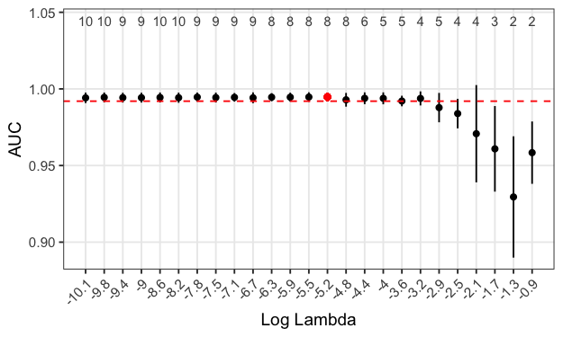

```r
plot(cv_results)
```

```r
cv_results$lambda_min
```

```
#> [1] 0.005755162
```

```r
cv_results$lambda_1se
```

```
#> [1] 0.03920946
```

To view a dataframe with the full cross-validation results (including both deviance and accuracy metrics), run `cv_results$results`.

```r
tail(cv_results$results)
```

```
#> # A tibble: 6 × 8
#>   lambda0 mean_dev sd_dev mean_acc sd_acc mean_auc  sd_auc nonzero
#>     <dbl>    <dbl>  <dbl>    <dbl>  <dbl>    <dbl>   <dbl>   <int>
#> 1  0.0576     37.2   11.5    0.955 0.0139    0.988 0.00958       5
#> 2  0.0845     42.3   13.1    0.944 0.0232    0.984 0.00964       4
#> 3  0.124      49.6   18.7    0.934 0.0313    0.971 0.0317        4
#> 4  0.182      60.1   14.6    0.925 0.0300    0.961 0.0279        3
#> 5  0.267      76.5   25.8    0.889 0.0478    0.929 0.0396        2
#> 6  0.392      64.9   18.1    0.918 0.0237    0.958 0.0203        2
```

## Fitting a Risk Score Model

```r
mod <- risk_mod(X, y, lambda0 = cv_results$lambda_1se)
```

The integer risk score model can be viewed by calling `mod$model_card`. An individual’s risk score can be calculated by multiplying each covariate response by its respective number of points and then adding all points together. In our example below, a patient with a ClumpThickness value of 5, a UniformityOfCellShape value of 1, a BareNuclei value of 1, and a BlandChromatin value of 3 would receive a score of $9(5) + 6(1) + 7(1) + 8(3) = 82$.

`mod$model_card`

|  | Points |
| --- | --- |
| ClumpThickness | 9 |
| UniformityOfCellShape | 6 |
| BareNuclei | 7 |
| BlandChromatin | 8 |

`mod$score_map`

| Score | Risk |
| --- | --- |
| 30 | 0.0009 |
| 60 | 0.0076 |
| 90 | 0.0617 |
| 120 | 0.3592 |
| 150 | 0.8270 |
| 180 | 0.9761 |
| 210 | 0.9971 |
| 240 | 0.9997 |
| 270 | 1.0000 |
| 300 | 1.0000 |

The function `get_risk()` can be used to calculate the risk from a given score (or a vector of scores). Likewise, the function `get_score()` calculates the score associated with a given risk (or vector of risk probabilities).

```r
get_risk(mod, score = 150)
```

```
#> [1] 0.8270133
```

```r
get_score(mod, risk = 0.8270133)
```

```
#> [1] 150
```

We can evaluate the model’s performance under different classification thresholds using the `get_metrics()` function.

```r
get_metrics(mod, threshold = seq(0.1, 0.9, 0.1))
```

```
#>   threshold_risk threshold_score  accuracy sensitivity specificity
#> 1            0.1            97.4 0.9604685   0.9832636   0.9481982
#> 2            0.2           108.7 0.9707174   0.9748954   0.9684685
#> 3            0.3           116.2 0.9692533   0.9623431   0.9729730
#> 4            0.4           122.4 0.9692533   0.9623431   0.9729730
#> 5            0.5           128.1 0.9677892   0.9497908   0.9774775
#> 6            0.6           133.8 0.9648609   0.9414226   0.9774775
#> 7            0.7           140.0 0.9604685   0.9205021   0.9819820
#> 8            0.8           147.5 0.9531479   0.8953975   0.9842342
#> 9            0.9           158.9 0.9428990   0.8577406   0.9887387
```

## Generic Functions

### summary

Running `summary()` on our model will return the intercept, the scores of each nonzero coefficient, the $\gamma$ multiplier value, the $\lambda_0$ regularizer value, the deviance, and the AIC.

```r
summary(mod)
```

```
#>
#> Intercept: -128.1023
#>
#> Non-zero coefficients:                      .
#> ClumpThickness        9
#> UniformityOfCellShape 6
#> BareNuclei            7
#> BlandChromatin        8
#>
#> Gamma (multiplier):  0.07145057
#> Lambda (regularizer):  0.03920946
#>
#> Deviance:  124.2174
#> AIC:  144.2174
```

### coef

A vector containing the risk score model intercept and integer coefficients can be accessed by calling `coef()` on the `risk_mod` object. This vector is also saved as `$beta` within the `risk_mod` object.

```r
coef(mod) # equivalently: mod$beta
```

```
#>                Intercept           ClumpThickness     UniformityOfCellSize
#>                -128.1023                   9.0000                   0.0000
#>    UniformityOfCellShape         MarginalAdhesion SingleEpithelialCellSize
#>                   6.0000                   0.0000                   0.0000
#>               BareNuclei           BlandChromatin           NormalNucleoli
#>                   7.0000                   8.0000                   0.0000
#>                  Mitoses
#>                   0.0000
```

We can map our integer score model to an equivalent logistic regression model by multiplying the integer and coefficients by $\gamma$ (saved as `$gamma` in the `risk_mod` object).

```r
coef(mod) * mod$gamma
```

```
#>                Intercept           ClumpThickness     UniformityOfCellSize
#>               -9.1529791                0.6430551                0.0000000
#>    UniformityOfCellShape         MarginalAdhesion SingleEpithelialCellSize
#>                0.4287034                0.0000000                0.0000000
#>               BareNuclei           BlandChromatin           NormalNucleoli
#>                0.5001540                0.5716045                0.0000000
#>                  Mitoses
#>                0.0000000
```

The `risk_mod` object stores a `glm` object of this non-integer logistic regression model as `$glm_mod`.

```r
coef(mod$glm_mod)
```

```
#>                Intercept           ClumpThickness     UniformityOfCellSize
#>               -9.1529791                0.6430551                0.0000000
#>    UniformityOfCellShape         MarginalAdhesion SingleEpithelialCellSize
#>                0.4287034                0.0000000                0.0000000
#>               BareNuclei           BlandChromatin           NormalNucleoli
#>                0.5001540                0.5716045                0.0000000
#>                  Mitoses
#>                0.0000000
```

### predict

Running `predict()` on a `risk_mod` object allows for three types of prediction, as the `type` parameter can be set to either `'link'`, `'response'`, or `'score'`. These first two options are the same as when `predict()` is run on a logistic `glm` object. The added `'score'` option returns each subject’s score, as calculated from the integer coefficients in the risk score model.

The table below compares the three possible prediction types for five example subjects.

Comparison of `predict()` outputs

| Covariates CT | Covariates UCS | Covariates BN | Covariates BC | Prediction ‘score’ | Prediction ‘link’ | Prediction ‘response’ |
| --- | --- | --- | --- | --- | --- | --- |
| 5 | 1 | 1 | 3 | 82 | -3.29 | 0.036 |
| 5 | 4 | 10 | 3 | 163 | 2.49 | 0.924 |
| 3 | 1 | 2 | 3 | 71 | -4.08 | 0.017 |
| 6 | 8 | 4 | 3 | 154 | 1.85 | 0.864 |
| 4 | 1 | 1 | 3 | 73 | -3.94 | 0.019 |

The ‘score’ is a linear combination of the covariates and their integer coefficients:

- $\text{score} = 9(\text{CT}) + 6(\text{UCS}) + 7 (\text{BN}) + 8(\text{BC})$

The ‘link’ is a linear combination of the covariates using the full logistic regression equation:

- $\text{link} = -9.15 + 0.643(\text{CT}) + 0.429(\text{UCS}) + 0.500(\text{BN}) + 0.572(\text{BC})$

The ‘response’ converts these link values to probabilities:

- $\text{response} = e^{\text{link}}/(1+e^{\text{link}})$

### plot

The relationship between scores and risk can be visualized by calling `plot()` on a `risk_mod` object.

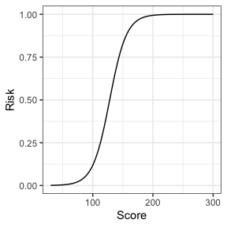

```r
plot(mod, score_min = 30, score_max = 300)
```